# IE 425 TERM PROJECT

## Özlem Şenel - 2017402117

## Oya Hoban - 2018402150

## 1 - INTRODUCTION

In this project we should use the given data which is about Kobe Bryant’s basketball career. It contains the location and circumstances of every field goal attempted by Kobe Bryant during his career. We are trying to predict whether the shot made flag. In order to achieve this goal, we split the train data into train and test sets, and try different methods to find the best one in terms of Area Under the Curve (AUC) values.

## 2 - DATA MANIPULATION

Firstly, we can observe that there is a large amount of input attributes in the data. It would be wise that we try to eliminate some of the attributes that may indicate close concepts. We see that there are two parameters for x and y coordinates, taking their euclidean distance from (0,0) location would reduce our number of attributes.

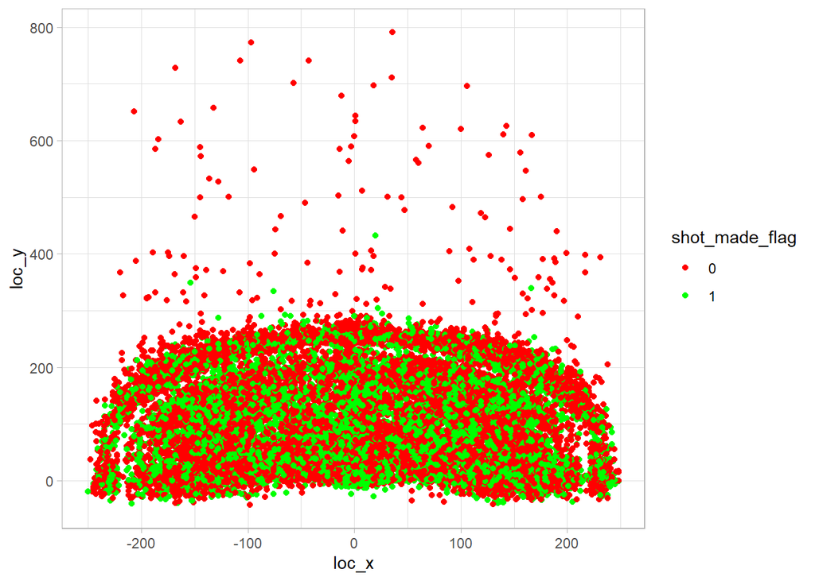

```
##   train_data.loc_x train_data.loc_y train_data.loc
## 1             -157                0       157.0000
## 2             -101              135       168.6001
## 3              138              175       222.8654
## 4                0                0         0.0000
## 5             -145              -11       145.4166
## 6              -33              125       129.2826
```

Also, we made plot with longtitude and latitude attributes and decided that there is correlation between location x and y attributes and these attributes. Because of that reason, it would be wise to eliminate these two attributes to avoid large amount of data.

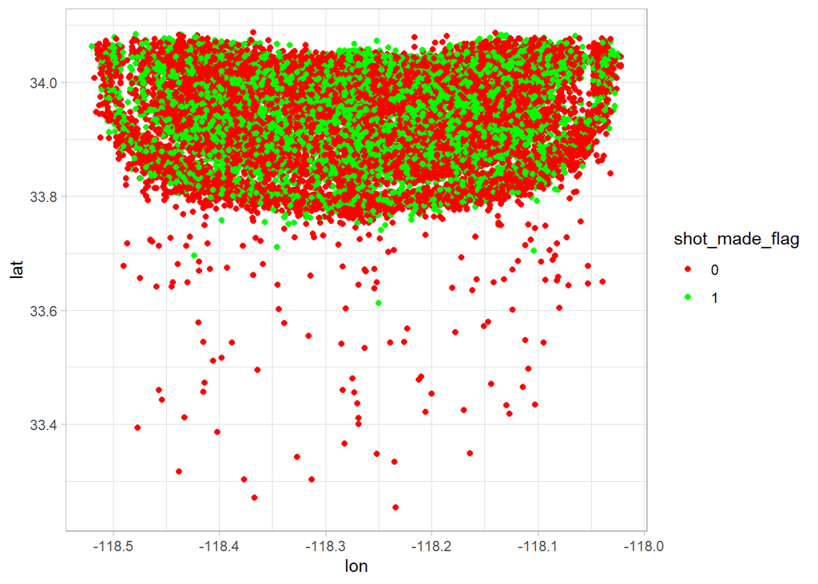

Secondly, we can combine the minutes and seconds remaining into a times remaining attribute.

```
##   train_data.minutes_remaining train_data.seconds_remaining
## 1                           10                           22
## 2                            7                           45
## 3                            6                           52
## 4                            6                           19
## 5                            9                           32
## 6                            3                           36
##   train_data.time_remaining
## 1                       622
## 2                       465
## 3                       412
## 4                       379
## 5                       572
## 6                       216
```

Another attribute that we can inspect is matchup attribute. Matchup includes whether the game is at home or at opponent’s home. As opponent attribute is already in the data, we can reduce the matchup attribute to 2 levels which ‘ishome’ or not.

[output not shown]

The data still has many input attributes. Game Date is one of the attributes which has large amount of levels. As we can see on the table, season is more aggregated version of game date, so we can discard game date and use season for shorter run time of the model. Also, team ID and team name attributes that have one level, so we can exclude them from the data.

```
##   train_data.game_date train_data.season
## 1           31.10.2000           2000-01
## 2           31.10.2000           2000-01
## 3           31.10.2000           2000-01
## 4           31.10.2000           2000-01
## 5           31.10.2000           2000-01
## 6           31.10.2000           2000-01
```

## 3 - MODELS

We made data manipulation and made the data easier for our models which will be helpful for the next steps. We can try different models to decide on the best model that we can use for our final prediction on the given test set. So, we search for the largest value for Area Under the Curve.

We will try 3 models for predictions:

- Modeling with GLM
- Modeling with Rpart
- Modeling with GBM

### Modeling with GLM

Because action type and game ID attributes have large amount of levels, when we split the given train data, some levels aren’t split equally. So, we can disregard these levels for only testing purposes.The AUC value for GLM model is 0.6641.

```
## Area under the curve: 0.6641
```

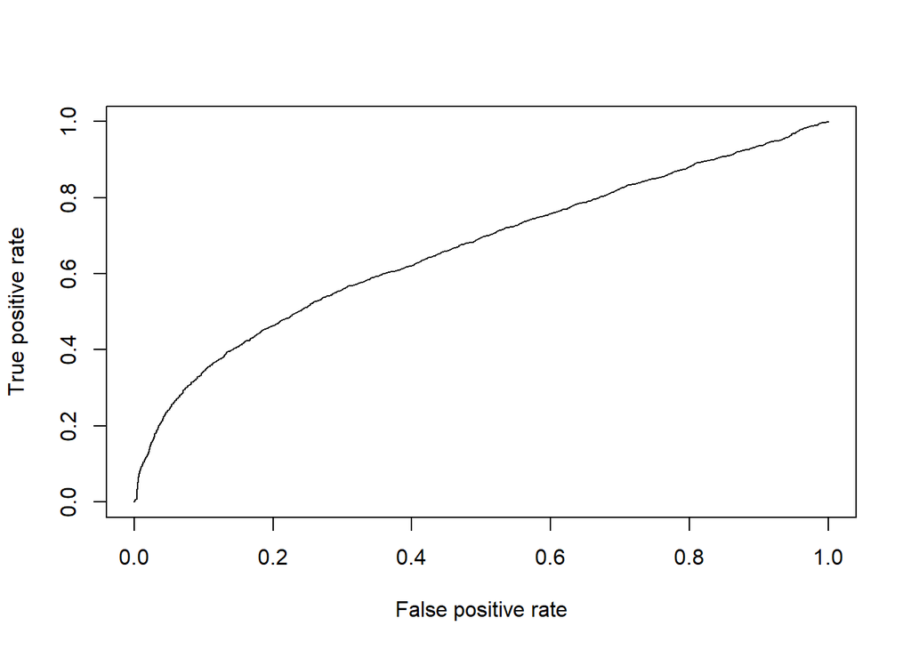

```
## [1] 0.6640537
```

### Modeling with Rpart

We use caret package for our first model. The best cp value for rpart with 10-fold cross validation model is 0.002. The accuracy value is 0.6833 and AUC value is 0.6643.

```
## Area under the curve: 0.6643
```

```
## Confusion Matrix and Statistics
##
##           Reference
## Prediction    0    1
##          0 3233 1587
##          1  610 1508
##
##                Accuracy : 0.6833
##                  95% CI : (0.6722, 0.6943)
##     No Information Rate : 0.5539
##     P-Value [Acc > NIR] : < 2.2e-16
##
##                   Kappa : 0.3389
##
##  Mcnemar's Test P-Value : < 2.2e-16
##
##             Sensitivity : 0.4872
##             Specificity : 0.8413
##          Pos Pred Value : 0.7120
##          Neg Pred Value : 0.6707
##              Prevalence : 0.4461
##          Detection Rate : 0.2174
##    Detection Prevalence : 0.3053
##       Balanced Accuracy : 0.6643
##
##        'Positive' Class : 1
##
```

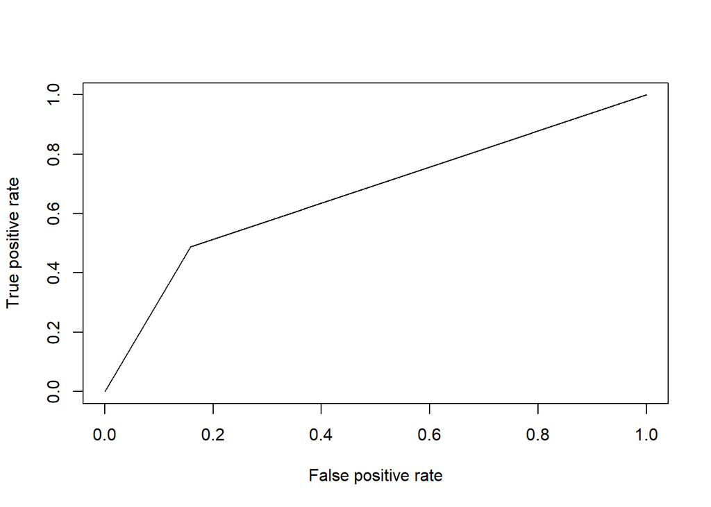

```
## [1] 0.6642537
```

### Modeling with GBM

For second model, we use caret package as well. Accuracy was used to select the optimal model using the largest value. The final values used for the model were n.trees = 100, interaction.depth = 4, shrinkage = 0.1, n.minobsinnode = 10. and accuracy = 0.6881. AUC value for the model is 0.6673.

```
## Area under the curve: 0.6673
```

```
## Confusion Matrix and Statistics
##
##           Reference
## Prediction    0    1
##          0 3305 1626
##          1  538 1469
##
##                Accuracy : 0.6881
##                  95% CI : (0.677, 0.699)
##     No Information Rate : 0.5539
##     P-Value [Acc > NIR] : < 2.2e-16
##
##                   Kappa : 0.3465
##
##  Mcnemar's Test P-Value : < 2.2e-16
##
##             Sensitivity : 0.4746
##             Specificity : 0.8600
##          Pos Pred Value : 0.7319
##          Neg Pred Value : 0.6702
##              Prevalence : 0.4461
##          Detection Rate : 0.2117
##    Detection Prevalence : 0.2893
##       Balanced Accuracy : 0.6673
##
##        'Positive' Class : 1
##
```

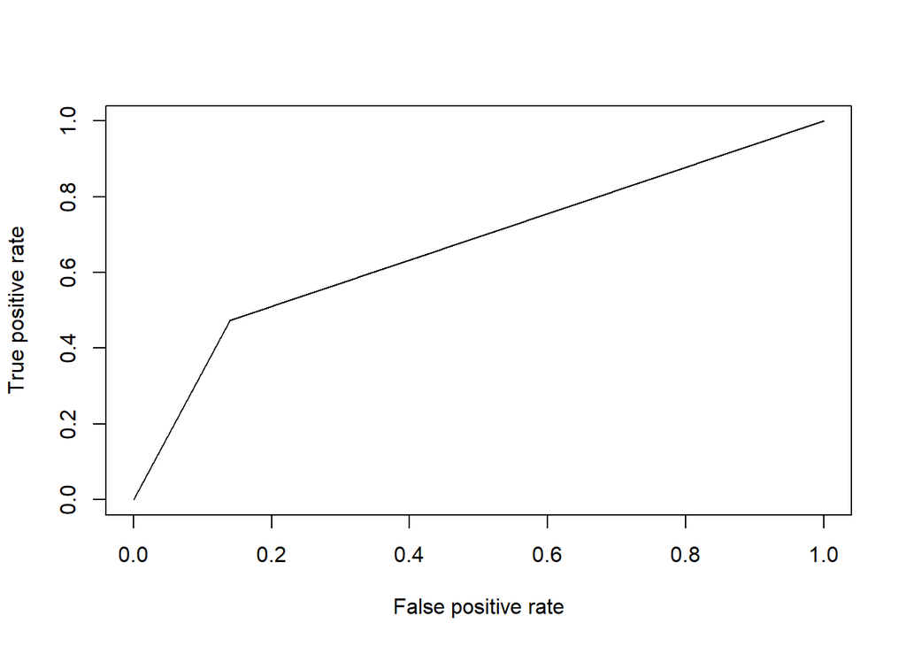

```
## [1] 0.6673209
```

## 4 - PREDICTIONS WITH FINAL MODEL

While testing for possible models for our predictions, the largest AUC value we have obtained is for the GBM model and the final values used for the model were n.trees = 100, interaction.depth = 4, shrinkage = 0.1, n.minobsinnode = 10. We build or model on the original train dataset and obtain our predictions using the final model.

## 5 - CONCLUSION

For this assignment, we made predictions about Kobe Bryant’s shot made flags. We made data manipulation and tried different models. We selected GBM model because it gave us the biggest AUC value which was an indicator that it was the best among them.